[Jupyter notebook]

$$\require{color} \require{cancel} \def\tf#1{{\mathrm{FT}\left\{ #1 \right\}}} \def\flecheTF{\rightleftharpoons } \def\TFI#1#2#3{{\displaystyle{\int_{-\infty}^{+\infty} #1 ~e^{j2\pi #2 #3} ~\dr{#2}}}} \def\TF#1#2#3{{\displaystyle{\int_{-\infty}^{+\infty} #1 ~e^{-j2\pi #3 #2} ~\dr{#2}}}} \def\sha{ш} \def\dr#1{\mathrm{d}#1} \def\egalpardef{\mathop{=}\limits^\triangle} \def\sinc#1{{\mathrm{sinc}\left( #1 \right)}} \def\rect{\mathrm{rect}} \definecolor{lightred}{rgb}{1,0.1,0} \def\myblueeqbox#1{{\fcolorbox{blue}{lightblue}{$ extcolor{blue}{ #1}$}}} \def\myeqbox#1#2{{\fcolorbox{#1}{light#1}{$ extcolor{#1}{ #2}$}}} \def\eqbox#1#2#3#4{{\fcolorbox{#1}{#2}{$\textcolor{#3}{ #4}$}}} % border|background|text \def\eqboxa#1{{\boxed{#1}}} \def\eqboxb#1{{\eqbox{green}{white}{green}{#1}}} \def\eqboxc#1{{\eqbox{blue}{white}{blue}{#1}}} \def\eqboxd#1{{\eqbox{blue}{lightblue}{blue}{#1}}} \def\E#1{\mathbb{E}\left[#1\right]} \def\ta#1{\left<#1\right>} \def\egalparerg{{\mathop{=}\limits_\mathrm{erg}}} \def\expo#1{\exp\left(#1\right)} \def\d#1{\mathrm{d}#1} \def\wb{\mathbf{w}} \def\sb{\mathbf{s}} \def\xb{\mathbf{x}} \def\Rb{\mathbf{R}} \def\rb{\mathbf{r}} \def\mystar{{*}} \def\ub{\mathbf{u}} \def\wbopt{\mathop{\mathbf{w}}\limits^\triangle} \def\deriv#1#2{\frac{\mathrm{d}#1}{\mathrm{d}#2}} \def\Ub{\mathbf{U}} \def\db{\mathbf{d}} \def\eb{\mathbf{e}} \def\vb{\mathbf{v}} \def\Ib{\mathbf{I}} \def\Vb{\mathbf{V}} \def\Lambdab{\mathbf{\Lambda}} \def\Ab{\mathbf{A}} \def\Bb{\mathbf{B}} \def\Cb{\mathbf{C}} \def\Db{\mathbf{D}} \def\Kb{\mathbf{K}} \def\sinc#1{\mathrm{sinc\left(#1\right)}} $$

# Démonstration du notebook IPython

## Fonctionnalités

Le notebook IPython est un document "*vivant*" qui permet

- d'intégrer des commentaires, du texte, des explications,
- des mathématiques,
- du code,
> - exécutable
- des images, liens multimédias
- des widgets

**Raccourcis clavier** Esc-H Puis voir la suite...

On peut énumérer, mettre en gras, en italique, faire des liens

Deux types de cellules :

- des cellules Markdown (texte)
- des cellules de code

On peut utiliser Python comme un calculateur

```python
a=1
b=2
print(a+b)
```

```
3
```

Ou encore faire des fonctions

```python
def myfunction(x,y=2):
    """effectue la somme de x et y
    avec y=2 par défaut
    """
    return x+y
myfunction(2,3)
```

```
5
```

### Par exemple

La transformée de Fourier est définie par $$ X(f) = \int_{-\infty}^{+\infty} x(t) e^{-j2\pi ft} \text{d}t. \label{eq:Fou} $$ Bien entendu, en pratique on doit utiliser une version numérique, comme $$ X(f) = \sum_{n=-\infty}^{+\infty} x(n) e^{-j2\pi fn}. \label{eq:Fou_discret} $$ Sous réserve qu'on sache calculer des sommes infinies, et puis il reste que $f$ est continue.

Fourier était un type sympa. Voici son portrait:

[figure not shown]

```python
from IPython.display import IFrame
IFrame('https://fr.wikipedia.org/wiki/Joseph_Fourier', width=700, height=350)
```

[interactive chart not shown]

Représentons une sinusoïde :

```python
sin(10)
#sin(pi/4)
```

```
-0.5440211108893698
```

```python
f=0.05
s=sin(2*pi*f*arange(0,200))
s[0:10]
```

```
array([0.        , 0.30901699, 0.58778525, 0.80901699, 0.95105652,
       1.        , 0.95105652, 0.80901699, 0.58778525, 0.30901699])
```

```
(-1.2, 1.2)
```

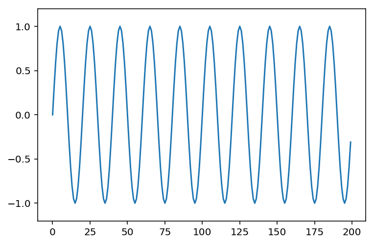

```python
plot(s)
ylim([-1.2, 1.2])
```